# Weekly Energy Charts

August 05, 2022

[Sign up here to get on our email list](https://docs.google.com/forms/d/e/1FAIpQLSckqeGjUvIlhveVyjmkXe913tzQRLANqPNQzEZTUQD2hQxH8g/viewform?usp=pp_url)

# Featured Stories

## The Giant Swiss Water Battery

#### Debosree Mukherjee

Nant de Drance, a “water battery” located in Switzerland began its operations in July and has [an energy storage capacity equivalent to 400,000 electric car batteries](https://www.cnn.com/2022/08/01/world/water-battery-switzerland-renewable-energy-climate-scn-hnk-spc-intl/index.html). It is a giant pumped storage hydroelectric facility and is expected to play a big role in Europe’s transition to renewable energy.

Wind and solar power create inconsistent power supply. Variable-speed pump turbine-powered water batteries such as Nant de Drance can stabilize the electricity grid. The plant has reversible turbines and can quickly go from storing to providing electricity.

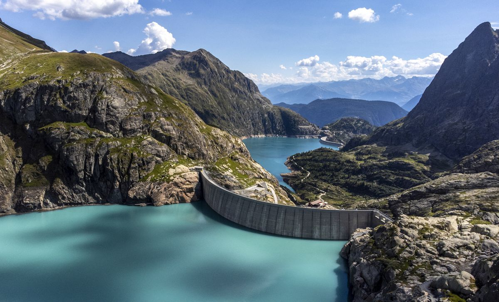

Image via [Reuters](https://www.reuters.com/business/sustainable-business/switzerlands-new-energy-asset-hydro-plant-with-capacity-charge-400000-car-2022-08-05/).

The cost to develop this plant was $2 billion and it took 14 years to complete. 17 kilometers of subterranean tunnels were excavated through the Alps. It has six turbines that are stored 600 meters below ground in a giant cavern. Two existing water reservoirs were re-purposed for this project, and they now hold more water than 6,500 Olympic-sized swimming pools! The plant can store 20 million kWh of potential energy, enough to power 900,000 homes.

Europe is hoping to become the first climate-neutral continent and aims for 45% of its total electricity supply to come from renewable sources by 2030. High-capacity storage facilities like Nant de Drance are essential to meet this goal.

## Cutting Oilsands’ Emissions

#### Erica Beattie

The [Financial Post](https://calgaryherald.com/business/energy/time-is-incredibly-tight-new-report-adds-clarity-to-challenge-of-cutting-oilsands-emissions) released an article earlier this week on a new report from S&P Global discussing the challenges of cutting oilsands’ emissions. Production in Canada’s oilsands sector has nearly doubled in the past decade or so, but now it will have to reverse this in order to meet the country’s goal of 40 per cent climate change reduction by 2030. The report touches on how difficult this will be given the time constraint and the scale of investment needed to achieve emission reductions.

The federal government has also set [mandates in the transportation sector](https://www.canada.ca/en/transport-canada/news/2022/04/minister-of-transport-announces-the-expansion-of-the-incentives-for-zero-emission-vehicles-program.html) requiring that all new vehicles sold must be zero-emission by 2030. These are large asks for both industries that will heavily impact each one, and many are questioning the feasibility of these aggressive cuts.

Carbon capture, which is the method of emissions reduction preferred by the oil sands industry, is discussed in the report. Alberta has already seen some investment in this technology, for example [Shell’s Quest project](https://www.shell.ca/en_ca/about-us/projects-and-sites/quest-carbon-capture-and-storage-project.html) which was completed in 2016. But the province requires much more capture and sequestration capacity if industry is to meet its stated goals, let alone these new federal targets. And there’s a short amount of time to get it done.

## Offshore Wind Project Queue Doubles

#### [Yousaff Habib](https://www.linkedin.com/in/yousaff-habib-6684891a5/)

EnergyPulse claims that the global pipeline for offshore wind projects — projects that are operational, under construction, consented to or planned — has doubled in the past year, from 429 GW of capacity to 846 GW. Offshore wind projects have become increasingly popular. Generating [substantially](https://marinerenewables.ca/facts/offshore-wind-energy/) more energy as a result of the higher wind speeds, offshore wind projects are a sky part of the future of renewable electricity. China, the UK and the USA are leading in offshore wind development, but Canada has a promising landscape for such projects, with [great wind resources available](https://policyoptions.irpp.org/magazines/february-2022/canada-offshore-wind-power/#:~:text=The%20continent%20now%20has%20116,wind%20power%20capacity%20by%202030.). Canada has plans for [31 offshore farm projects in the works.](https://www.4coffshore.com/windfarms/canada/)

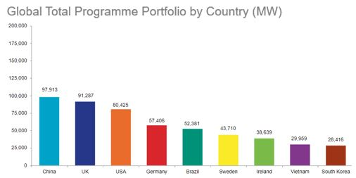

Capacity Per Country

This data also reveal some interesting insights about other countries. While most currently-installed capacity is in western countries, sizeable levels are present in Asian and South American countries too. This is promising, as it indicates that efforts are being made globally. There are also implications for the utility of this specific form of renewable energy. While not feasible for landlocked countries, it does allow countries with limiting geographical features (i.e. lack of space, uneven terrain, etc.) to embrace renewable energy.

With zero emission goals present in much of the western, and similar goals becoming more prevalent in the rest of the world, offshore wind is an important resource to watch in the coming years.

# Oil

## Weekly Crude Prices

### Feature Crude

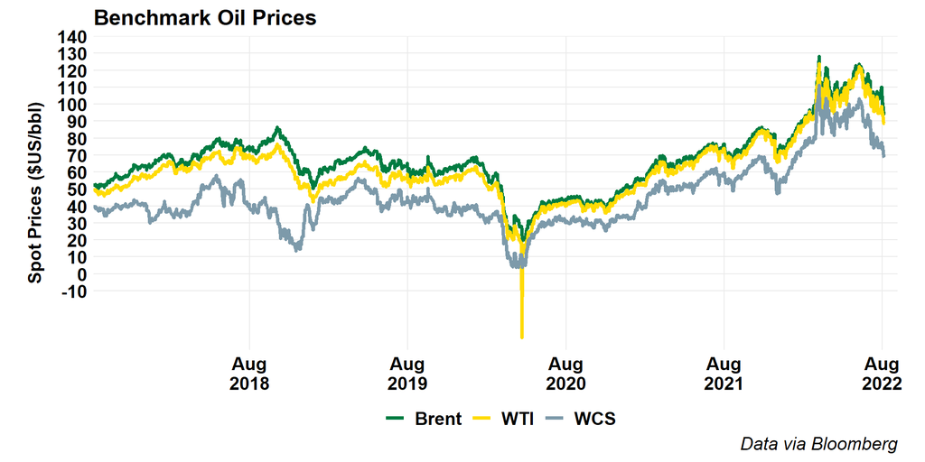

### Alberta Crude

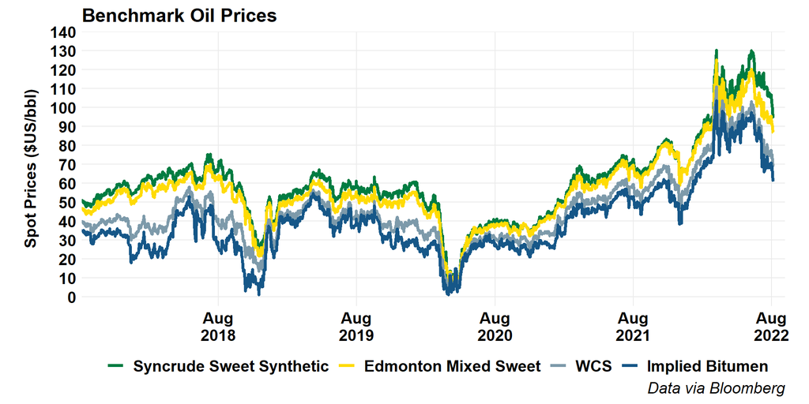

### Alberta Crude (Short)

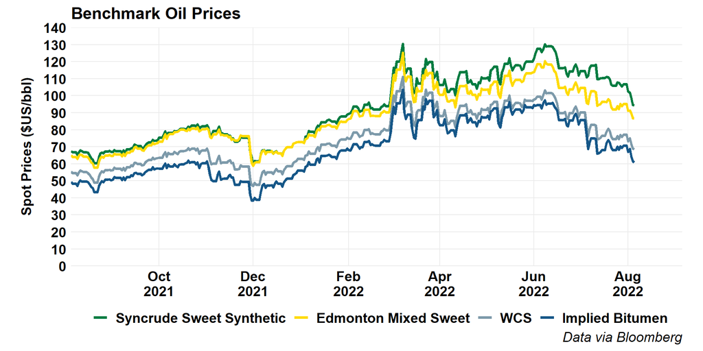

### US Crude

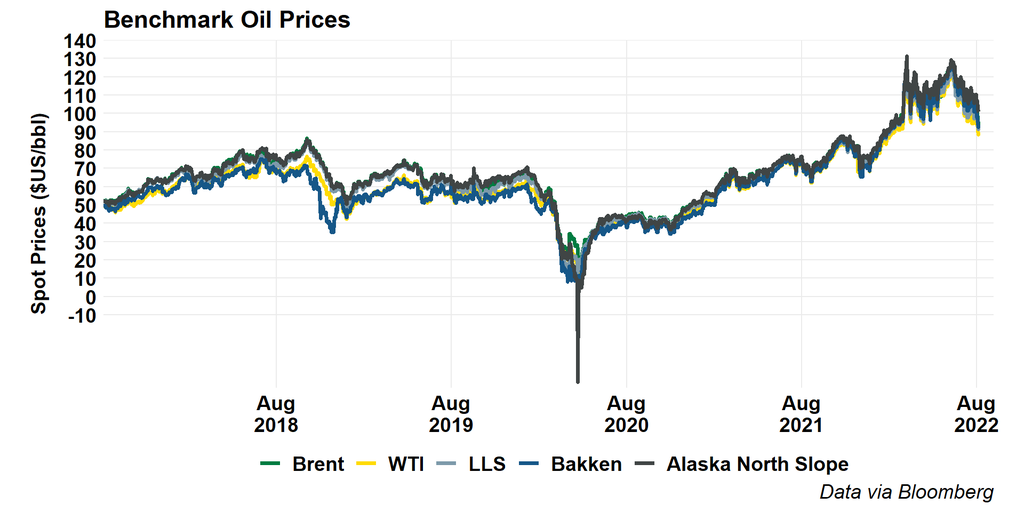

### Global Crude

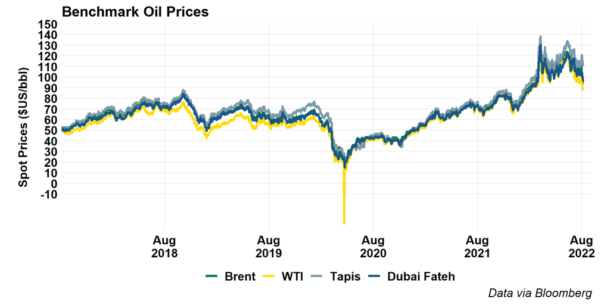

## Oil Price Differentials

### Brent-WTI

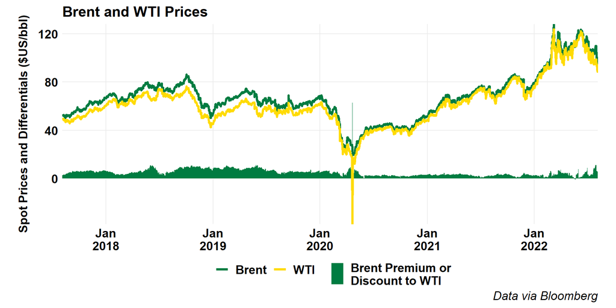

### WTI-WCS

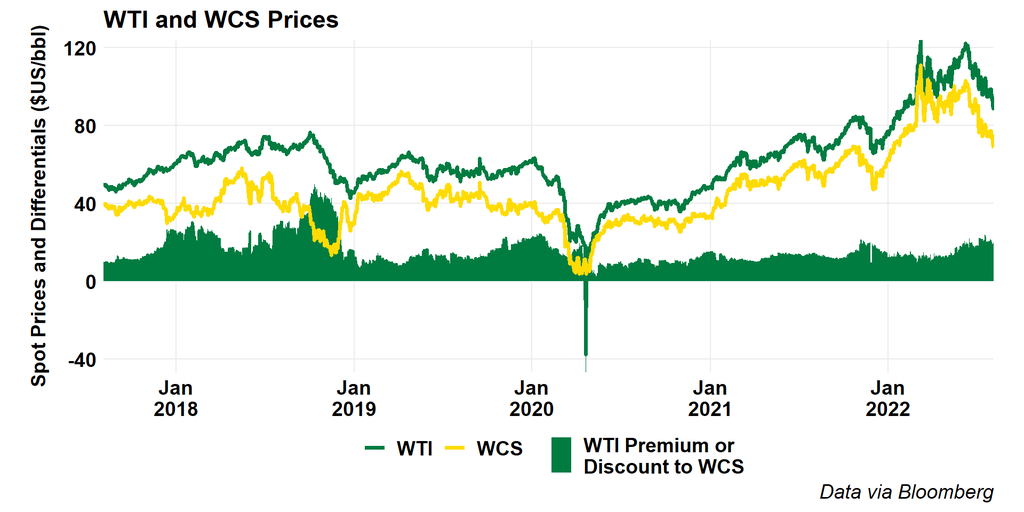

### WTI-WCS (Short)

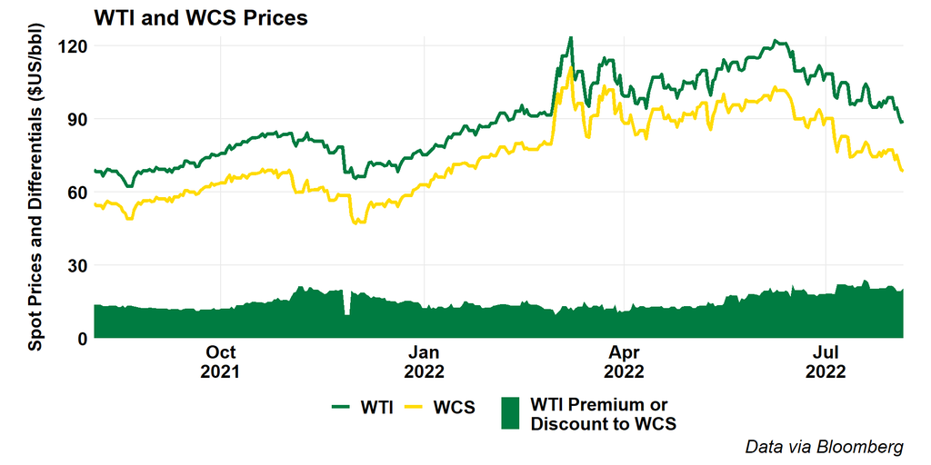

### Maya-WCS

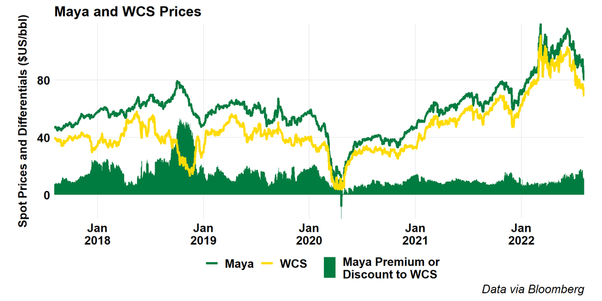

### WTI Cushing vs MEH

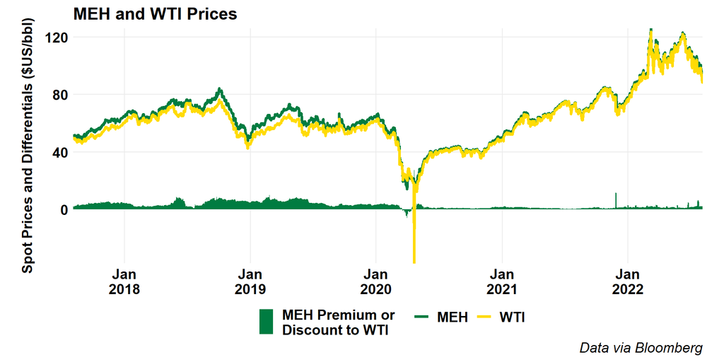

## Forward Curves

### WTI

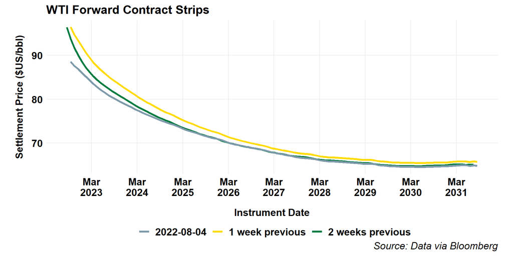

### Brent

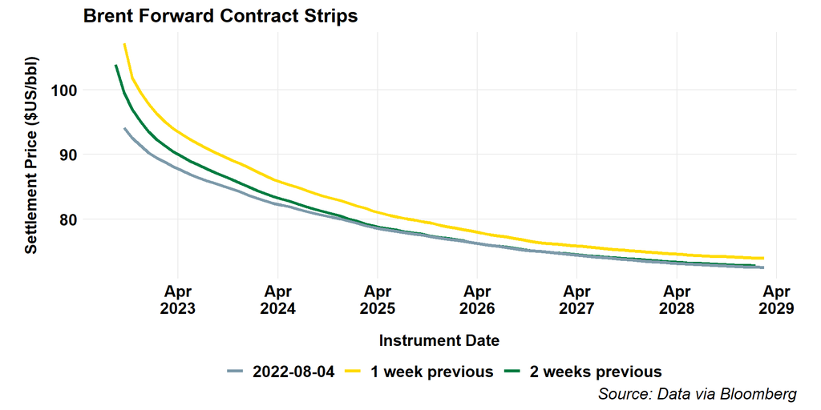

## Canadian Crude Supply and Disposition

### Production

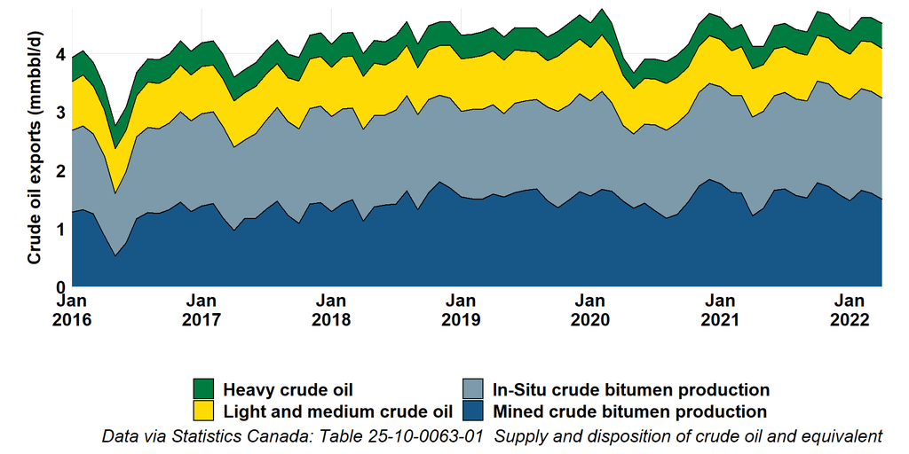

### Imports

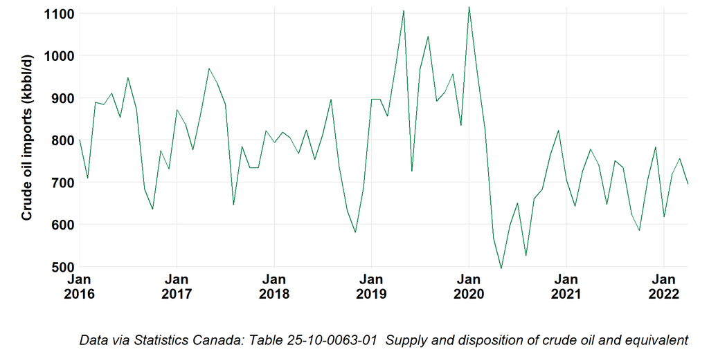

### Exports

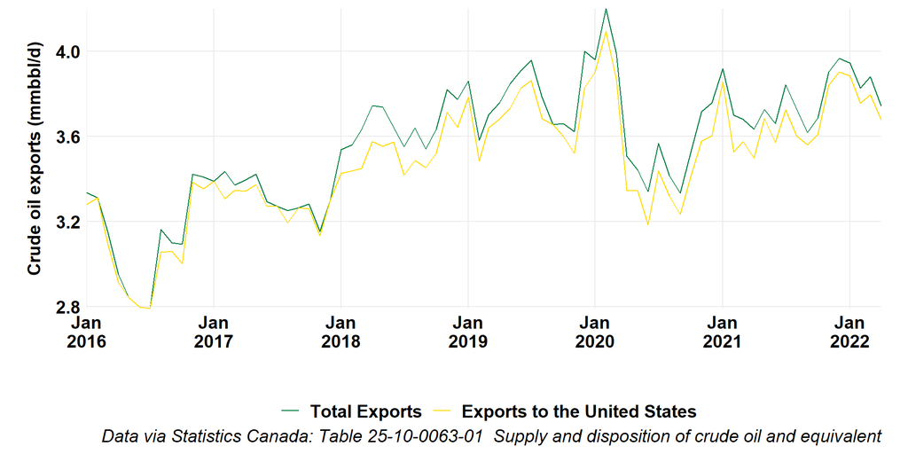

### Rail Exports

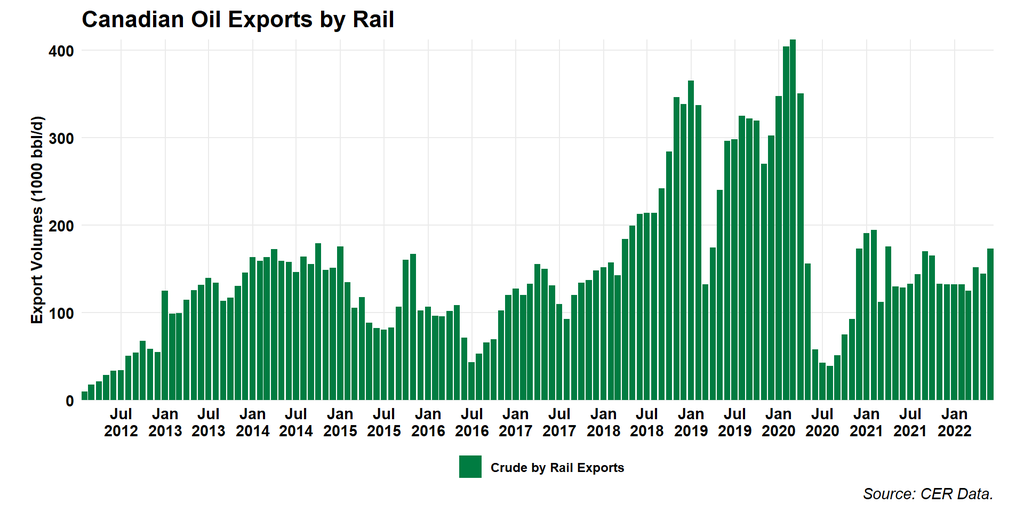

## US Oil

### Production

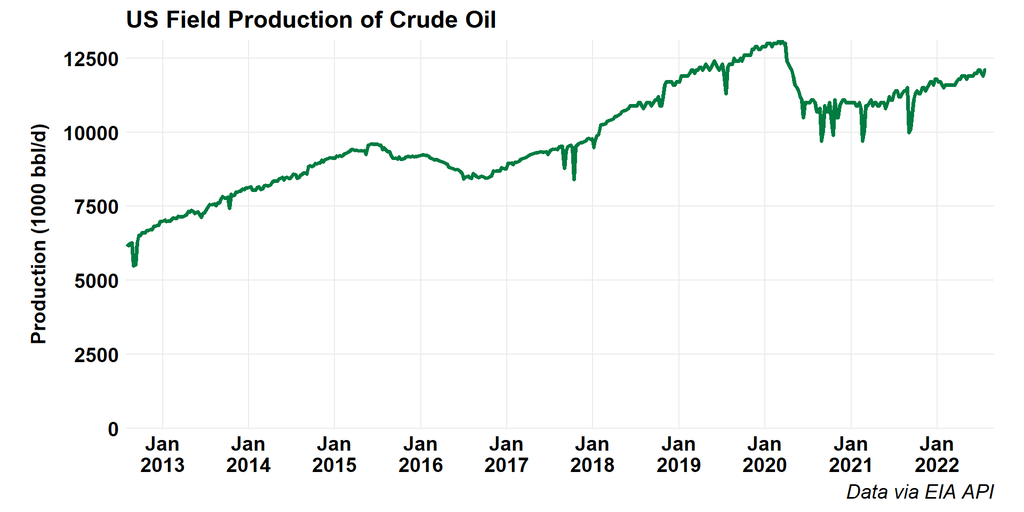

### LTO Production by Play

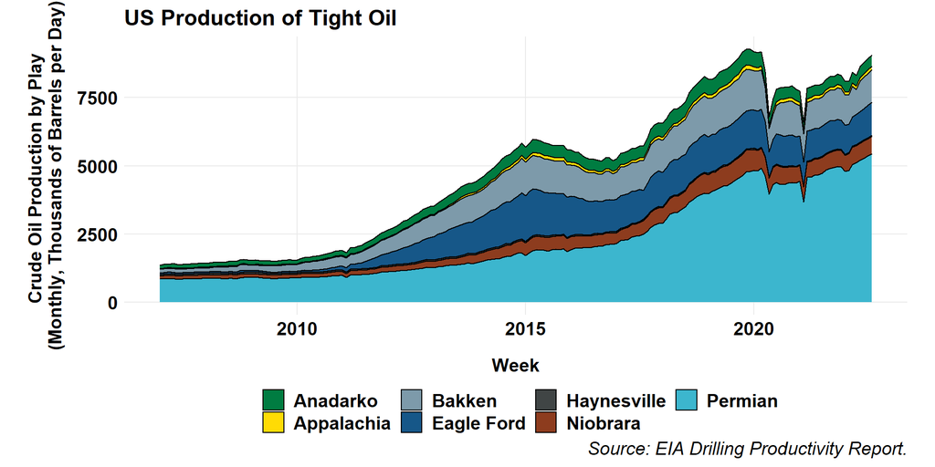

### Net Imports

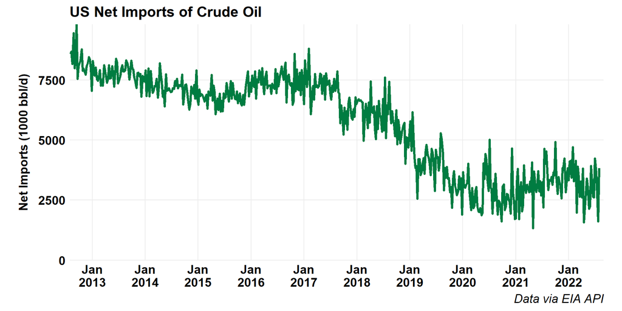

### Oil and Product Net Imports

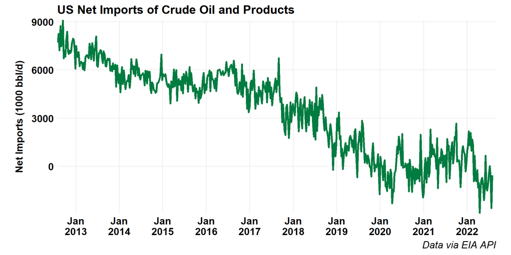

### Inventories

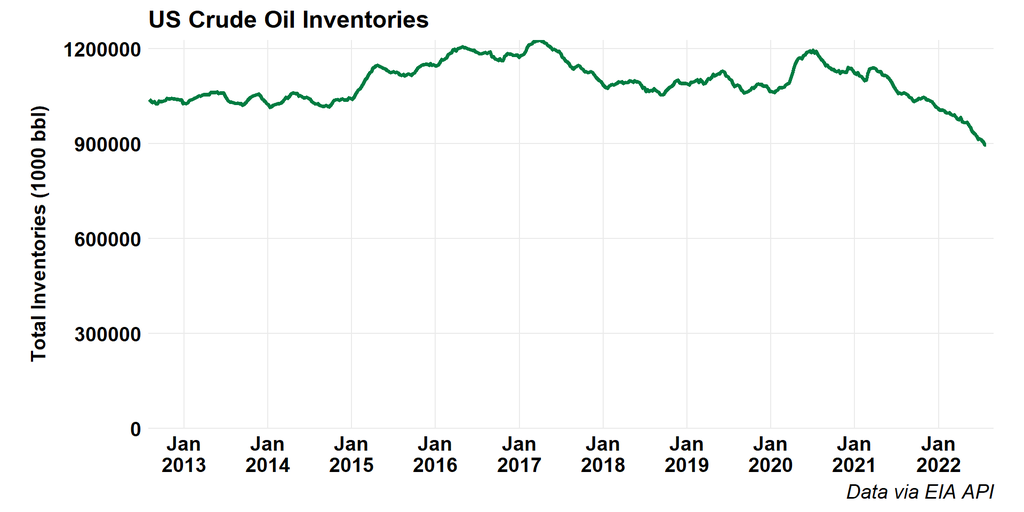

# Refined Products

## Canadian Gasoline Prices

### Map

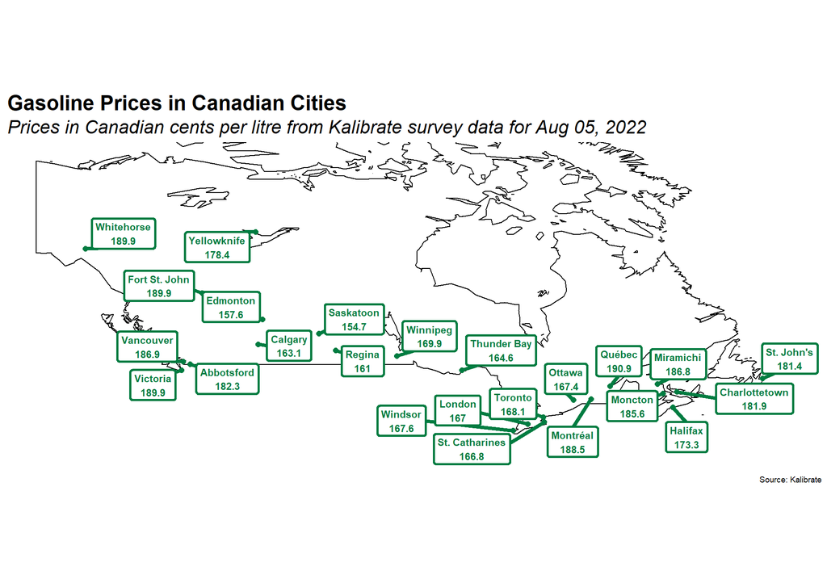

### Historic Gasoline Prices

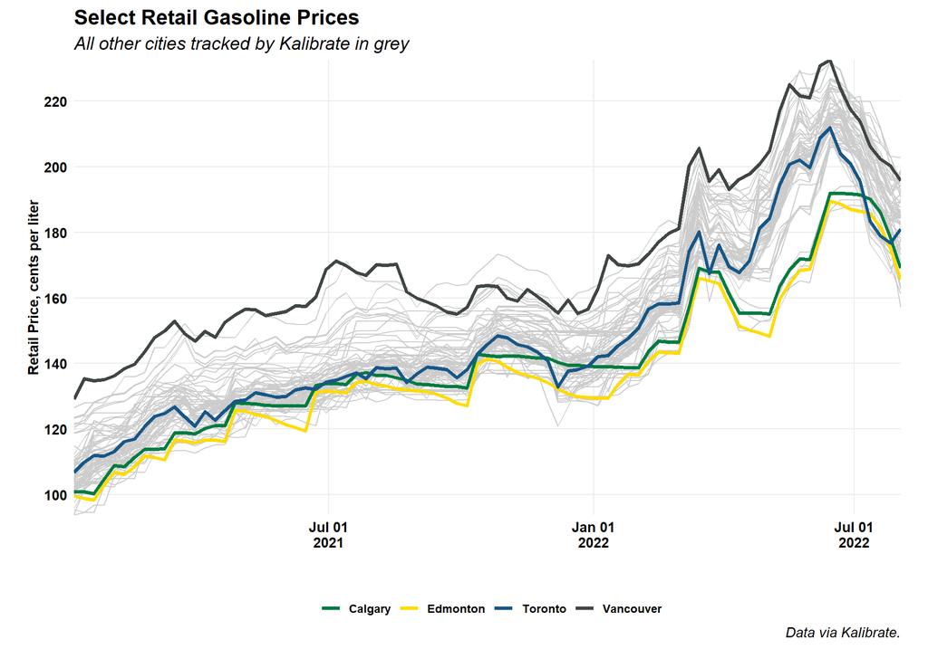

### Historic Gasoline Prices in BTC

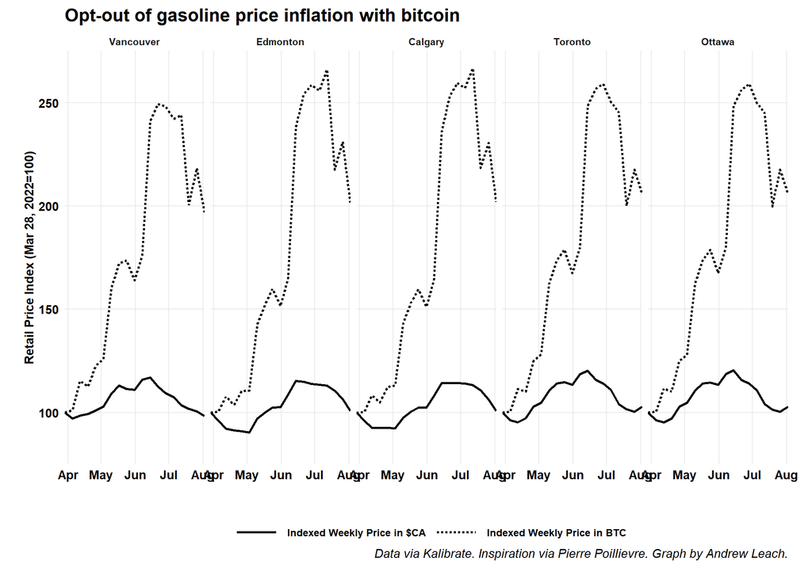